# Clase 1 — RMarkdown

Constanza Trujillo y José Ruiz-Tagle

13 noviembre 2025

> **Objetivo:** entender **qué es R Markdown**, cómo funciona la combinación **texto + código**, qué es un **chunk**, cómo controlar su ejecución con **opciones** (`echo`, `eval`, `include`, `results`, `message`, `warning`, `fig.*`), y cómo **compilar (Knit)** a **HTML** y **PDF**.

# 1 ¿Qué es R Markdown?

R Markdown es un formato que permite escribir documentos que mezclan **prosa** (Markdown) y **código ejecutable** (R, y otros).  
Al “tejer” el documento (Knit), **knitr** ejecuta el código, **rmarkdown** arma el informe y lo exporta a **HTML**, **PDF** o **Word**.

- **Markdown** = sintaxis ligera para dar formato (títulos, listas, negritas, tablas).
- **Chunks** = bloques de código R delimitados por `` ```{r} `` y `` ``` ``.
- **YAML** = cabecera al inicio entre `---` con **metadatos** (título, autor, fecha) y **formatos de salida**.

# 2 Anatomía de un `.Rmd`

Un archivo `.Rmd` típico tiene tres partes:

1. **YAML** (entre líneas `---`) con título/autor/fecha y `output:`.
2. **Prosa en Markdown** (texto con formato).
3. **Chunks de código** (ejecutables) y **código inline** (en línea) con `` `r` ``.

# 3 Chunks: crear, nombrar y ejecutar

En **RStudio**:

- Insertar chunk: **Ctrl/Cmd + Alt + I** o botón *Insert Chunk*.
- Estructura básica:

```r
# tu código aquí
```

- Ejecutar un chunk: ícono “Run” (triángulo) en el borde del chunk o **Ctrl/Cmd + Shift + Enter** para ejecutar el documento de arriba hacia abajo.

# 4 Opciones de chunk más usadas (knitr)

Estas van en la cabecera `{r ...}` o como **globales** en el chunk `setup`.

- `echo = TRUE/FALSE` → ¿se muestra el **código** en el informe?
- `eval = TRUE/FALSE` → ¿se **ejecuta** el código?
- `include = TRUE/FALSE` → ¿incluye **código + output** en el informe (aunque se ejecute)?
- `message = TRUE/FALSE` y `warning = TRUE/FALSE` → mostrar/ocultar mensajes y advertencias.
- `results = 'hide'|'asis'` → controlar salida textual.
- `fig.width`, `fig.height`, `fig.align`, `fig.cap`, `out.width` → control de gráficos.

> **Diferencias clave**:  
> • `echo=FALSE` oculta el **código**, pero muestra el **resultado**.  
> • `eval=FALSE` muestra el **código** sin ejecutarlo (no hay resultado).  
> • `include=FALSE` ejecuta pero **no** incluye nada en el informe (útil para cargas y setups).

# 5 Setup global de chunks

# 6 DEMO: texto, inline code y listas

**Markdown básico**

(Deja **una línea en blanco** antes de listas como esta.)

- **Negrita** con `**así**` y *cursiva* con `*así*`.
- Lista:
  - item 1
  - item 2

**Código inline**: hoy es 13-11-2025 y `mtcars` tiene 32 filas. *El texto inline (o código inline) en R Markdown es código R corto que se evalúa dentro de una línea de texto y su resultado se inserta en el párrafo al compilar. Se escribe entre backticks con r al inicio.*

# 7 Ejemplos de chunks y opciones

*mtcars es un dataset incorporado en R (viene “de fábrica”). Resume datos de 32 automóviles probados por la revista Motor Trend (1974), con 11 variables como consumo y desempeño.*

## 7.1 Chunk básico

```r
1 + 1   # suma simple
```

```
## [1] 2
```

```r
mean(c(1, 2, 3, 10))  # media de una serie de números
```

```
## [1] 4
```

## 7.2 `echo=FALSE` (oculta código, muestra resultados)

```
##    Min. 1st Qu.  Median    Mean 3rd Qu.    Max.
##   10.40   15.43   19.20   20.09   22.80   33.90
```

## 7.3 `eval=FALSE` (muestra código, no ejecuta)

```r
plot(mtcars$wt, mtcars$mpg)  # plot(x,y): dispersión; X=mtcars$wt (peso, 1000 lbs), Y=mtcars$mpg (rendimiento)
```

## 7.4 Gráfico con `fig.cap` y `out.width`

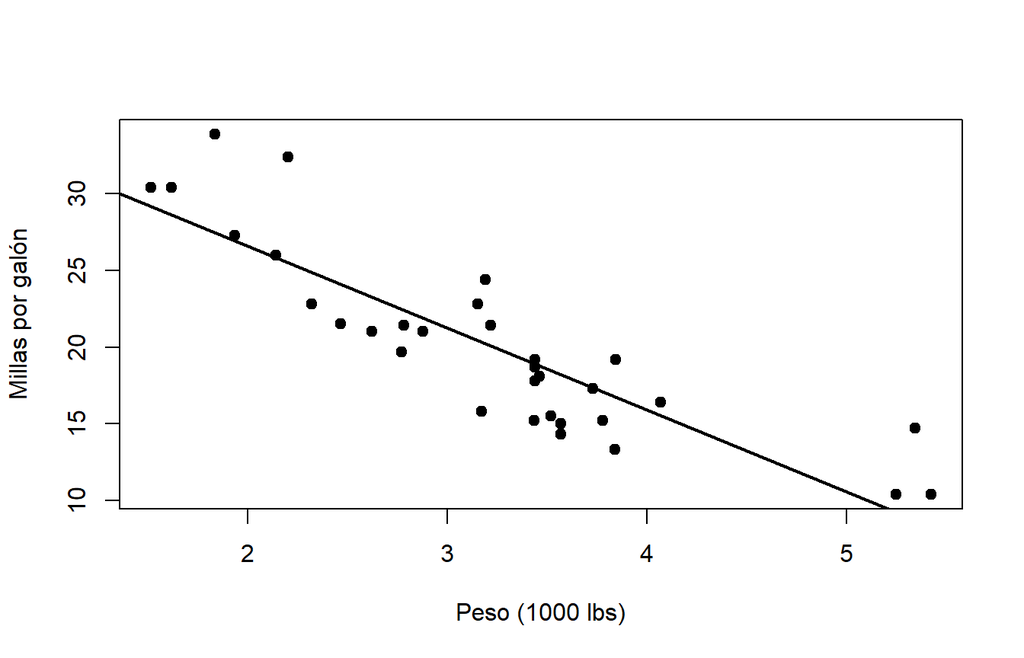

Relación peso vs rendimiento (mtcars)

```r
plot(mtcars$wt, mtcars$mpg,                       # dispersión X=wt (peso 1000 lbs), Y=mpg (millas/galón)
     pch = 19,                                    # tipo de punto: círculo sólido
     xlab = "Peso (1000 lbs)",                    # etiqueta eje X
     ylab = "Millas por galón")                   # etiqueta eje Y

abline(lm(mpg ~ wt, data = mtcars),              # añade la recta de regresión mpg ~ wt
       lwd = 2)                                  # grosor de la línea (más visible)
```

## 7.5 `message` y `warning`

```r
library(dplyr)            # Carga el paquete dplyr para manipulación de datos (pipes, group_by, summarise, etc.)
mtcars %>%                # Toma el data.frame mtcars y pásalo por la pipe (%>%) Ctrl + Shift + M
  group_by(cyl) %>%       # Agrupa las filas por número de cilindros (cyl: 4, 6, 8)
  summarise(              # Calcula resúmenes por cada grupo de 'cyl'
    mpg_prom = mean(mpg), # promedio de millas/galón dentro de cada grupo
    .groups = "drop")     # quita el atributo de agrupación en el resultado final
```

| cyl | mpg_prom |
| --- | --- |
| 4 | 26.66364 |
| 6 | 19.74286 |
| 8 | 15.10000 |

## 7.6 Tablas con `knitr::kable`

- head(iris): toma las primeras 6 filas del dataset iris (incluye Sepal/ Petal medidas y Species)
- knitr::kable(): crea una tabla “bonita” para el informe (funciona en HTML, PDF y Word)
- caption = “…” : pone un pie de tabla (se numera si el formato lo permite y usas fig/tab captions)
- con kableExtra se pueden crear múltiples tipos de tablas, con colores, con imágenes, con gráficos, etc.

```r
knitr::kable(
  head(iris), # datos a mostrar (primeras 6 filas)
  caption = "Primeras filas de iris") # título/pie de la tabla
```

Primeras filas de iris

| Sepal.Length | Sepal.Width | Petal.Length | Petal.Width | Species |
| --- | --- | --- | --- | --- |
| 5.1 | 3.5 | 1.4 | 0.2 | setosa |
| 4.9 | 3.0 | 1.4 | 0.2 | setosa |
| 4.7 | 3.2 | 1.3 | 0.2 | setosa |
| 4.6 | 3.1 | 1.5 | 0.2 | setosa |
| 5.0 | 3.6 | 1.4 | 0.2 | setosa |
| 5.4 | 3.9 | 1.7 | 0.4 | setosa |

```r
# --- Variantes útiles  -------------------------

# Alinear columnas: "l"=left, "c"=center, "r"=right (uno por columna)
 knitr::kable(head(iris), align = c("l","r","r","r","c"),
              caption = "Iris alineado")
```

Iris alineado

| Sepal.Length | Sepal.Width | Petal.Length | Petal.Width | Species |
| --- | --- | --- | --- | --- |
| 5.1 | 3.5 | 1.4 | 0.2 | setosa |
| 4.9 | 3.0 | 1.4 | 0.2 | setosa |
| 4.7 | 3.2 | 1.3 | 0.2 | setosa |
| 4.6 | 3.1 | 1.5 | 0.2 | setosa |
| 5.0 | 3.6 | 1.4 | 0.2 | setosa |
| 5.4 | 3.9 | 1.7 | 0.4 | setosa |

```r
# Renombrar encabezados de columnas:
 knitr::kable(head(iris),
              col.names = c("Largo Sépalo","Ancho Sépalo","Largo Pétalo","Ancho Pétalo","Especie"),
              caption = "Iris con encabezados en español")
```

Iris con encabezados en español

| Largo Sépalo | Ancho Sépalo | Largo Pétalo | Ancho Pétalo | Especie |
| --- | --- | --- | --- | --- |
| 5.1 | 3.5 | 1.4 | 0.2 | setosa |
| 4.9 | 3.0 | 1.4 | 0.2 | setosa |
| 4.7 | 3.2 | 1.3 | 0.2 | setosa |
| 4.6 | 3.1 | 1.5 | 0.2 | setosa |
| 5.0 | 3.6 | 1.4 | 0.2 | setosa |
| 5.4 | 3.9 | 1.7 | 0.4 | setosa |

```r
# En HTML puedes combinar con kableExtra para estilo avanzado:
if (knitr::is_html_output()) {
   knitr::kable(head(iris), caption = "Iris con estilo") |>
     kableExtra::kable_styling(full_width = FALSE) #no queremos que su ancho sea de toda la pantalla
 }
```

Iris con estilo

| Sepal.Length | Sepal.Width | Petal.Length | Petal.Width | Species |
| --- | --- | --- | --- | --- |
| 5.1 | 3.5 | 1.4 | 0.2 | setosa |
| 4.9 | 3.0 | 1.4 | 0.2 | setosa |
| 4.7 | 3.2 | 1.3 | 0.2 | setosa |
| 4.6 | 3.1 | 1.5 | 0.2 | setosa |
| 5.0 | 3.6 | 1.4 | 0.2 | setosa |
| 5.4 | 3.9 | 1.7 | 0.4 | setosa |

```r
library(dplyr)
library(kableExtra)
```

```r
text_tbl <-data.frame(
 Items= c("Item1", "Item2", "Item3"),
 Features =c(
 "Loremipsumdolorsit amet,consectetur adipiscingelit.Proinvehicula temporex.Morbimalesuadasagittis",
 "In euurna atmagnaluctusrhoncus quis innisl.Fusceinvelitvarius, posuere risuset,cursusaugue.",
 "Vivamus venenatisegestas eros uttempus. Vivamus idest nisi.Aliquam molestie erat etsollicitudin"
 )
 )
 kbl(text_tbl,booktabs =T)%>%
 kable_styling(full_width= F)%>%
 column_spec(1,bold = T,color= "red") %>%
 column_spec(2,width= "30em")
```

| Items | Features |
| --- | --- |
| Item1 | Loremipsumdolorsit amet,consectetur adipiscingelit.Proinvehicula temporex.Morbimalesuadasagittis |
| Item2 | In euurna atmagnaluctusrhoncus quis innisl.Fusceinvelitvarius, posuere risuset,cursusaugue. |
| Item3 | Vivamus venenatisegestas eros uttempus. Vivamus idest nisi.Aliquam molestie erat etsollicitudin |

```r
that_cell<-c(rep(F,7),T)
 mtcars[1:8,1:8] %>%
 kbl(booktabs =T,linesep = "") %>%
 kable_paper(full_width= F)%>%
 column_spec(2,color=spec_color(mtcars$mpg[1:8]),
 link = "https://haozhu233.github.io/kableExtra") %>%
 column_spec(6,color= "white",
 background= spec_color(mtcars$drat[1:8],end =0.7),
 popover = paste("am:",mtcars$am[1:8])) %>%
 column_spec(9,strikeout=that_cell,bold = that_cell,
 color= c(rep("black",7),"red"))
```

|  | mpg | cyl | disp | hp | drat | wt | qsec | vs |
| --- | --- | --- | --- | --- | --- | --- | --- | --- |
| Mazda RX4 | [21.0](https://haozhu233.github.io/kableExtra) | 6 | 160.0 | 110 | 3.90 | 2.620 | 16.46 | 0 |
| Mazda RX4 Wag | [21.0](https://haozhu233.github.io/kableExtra) | 6 | 160.0 | 110 | 3.90 | 2.875 | 17.02 | 0 |
| Datsun 710 | [22.8](https://haozhu233.github.io/kableExtra) | 4 | 108.0 | 93 | 3.85 | 2.320 | 18.61 | 1 |
| Hornet 4 Drive | [21.4](https://haozhu233.github.io/kableExtra) | 6 | 258.0 | 110 | 3.08 | 3.215 | 19.44 | 1 |
| Hornet Sportabout | [18.7](https://haozhu233.github.io/kableExtra) | 8 | 360.0 | 175 | 3.15 | 3.440 | 17.02 | 0 |
| Valiant | [18.1](https://haozhu233.github.io/kableExtra) | 6 | 225.0 | 105 | 2.76 | 3.460 | 20.22 | 1 |
| Duster 360 | [14.3](https://haozhu233.github.io/kableExtra) | 8 | 360.0 | 245 | 3.21 | 3.570 | 15.84 | 0 |
| Merc 240D | [24.4](https://haozhu233.github.io/kableExtra) | 4 | 146.7 | 62 | 3.69 | 3.190 | 20.00 | 1 |

## 7.7 `results='hide'` y `include=FALSE`

```r
# Se ejecuta pero no muestra resultados
x <- rnorm(1e5)      # Genera 100.000 (1e5) números aleatorios ~ N(0, 1) y los guarda en 'x'
                     #  rnorm(n) produce valores con media 0 y desviación estándar 1 por defecto.

media_x <- mean(x)   # Calcula la media (promedio) de esos 100.000 valores y la guarda en 'media_x'
                     #  Por la ley de los grandes números, este valor debería estar cerca de 0.
```

[output not shown]

# 8 ¿Cómo compilar (Knit)?

## 8.1 Desde RStudio

1. Guarda el `.Rmd`.
2. Usa la flecha del botón **Knit** para elegir **HTML** o **PDF**, y clic en **Knit**.

## 8.2 Con código (automatización)

```r
install.packages("rmarkdown")
# HTML
rmarkdown::render("clase01_demo.Rmd", output_format = "html_document")
# PDF
rmarkdown::render("clase01_demo.Rmd", output_format = "pdf_document")
```

# 9 Exportar a **PDF** (TinyTeX)

Para generar PDF necesitas LaTeX. La opción más simple es **tinytex**:

```r
install.packages("tinytex")
tinytex::install_tinytex()  # una sola vez
```

> Si ya tienes MiKTeX/TeX Live, no instales tinytex. Si faltan paquetes LaTeX: `tinytex::tlmgr_install("<paquete>")` o `tinytex::reinstall_tinytex()`.

# 10 HTML vs PDF vs Word

- **HTML**: liviano, interactivo (plegado de código, tablas paginadas), fácil de compartir.
- **PDF**: estable para impresión/entrega formal, requiere LaTeX.
- **Word**: editable por terceros.

Puedes definir múltiples salidas en `output:` y elegir desde la flecha de **Knit**.

# 11 Ejercicios

1. Crea un `.Rmd` con YAML mínimo (título/autor/fecha) y `output: html_document`.
2. Inserta **3 chunks**:
   - 1. cálculo simple (p.ej., media de un vector),
   - 2. un gráfico con `fig.cap`,
   - 3. una tabla con `knitr::kable`.
3. Juega con `echo`, `eval`, `include`, `message`, `warning`, `results`.
4. Agrega **código inline** con length(unique(iris$Species)).
5. Activa `code_folding: show` y **compila a HTML**.
6. Instala **tinytex** y **compila a PDF**.

# 12 Problemas comunes

- **No compila a PDF** → instala `tinytex` (o verifica LaTeX), reinicia RStudio y vuelve a knit.
- **Paquetes faltantes** → `install.packages("<paquete>")` o `tinytex::tlmgr_install("<paquete LaTeX>")`.
- **Rutas con tildes/espacios** → evita caracteres raros en carpetas.
- **Demasiados mensajes/advertencias** → usa `message=FALSE, warning=FALSE` o limpia el ambiente y re-knit.
- **Resultados/gráficos desordenados** → ajusta `fig.width/height`, `out.width`, `fig.align`